# **Описание проекта**

## Этап 4.3. Определение влияния рейтинга ESRB на продажи в отдельном регионе.

Чтобы выбрать регион для исследования, посмотрим, в каком регионе осуществлено больше всего продаж.

```python
print('Суммарный объём продаж в Северной Америке:', round((df['NA_sales'].sum()), 2), 'млн. долларов')
print('Суммарный объём продаж в Европе:', round((df['EU_sales'].sum()), 2), 'млн. долларов')
print('Суммарный объём продаж в Японии:', round((df['JP_sales'].sum()), 2), 'млн. долларов')
print('Суммарный объём продаж в остальных регионах:', round((df['Other_sales'].sum()), 2), 'млн. долларов')
```

```
Суммарный объём продаж в Северной Америке: 1901.16 млн. долларов
Суммарный объём продаж в Европе: 1286.37 млн. долларов
Суммарный объём продаж в Японии: 311.93 млн. долларов
Суммарный объём продаж в остальных регионах: 407.33 млн. долларов
```

Видим, что Северная Америка лидирует по суммарному объёму продаж, поэтому этот регион и выберем в качестве объекта исследования.

Чтобы оценить влияние рейтинга на продажи, можно воспользоваться коэффициентом корреляции и диаграммой рассеяния.

Отмечу, что ранее рейтинг был приведён в буквенном формате, однако мы предусмотрительно создали новое поле с его численным аналогом, так что теперь можем без труда посчитать корреляцию и построить диаграмму рассеяния.

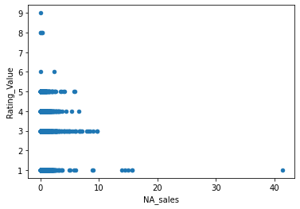

```python
df.plot(x = 'NA_sales', y = 'Rating_Value', kind = 'scatter')
plt.show()
```

На первый взгляд линейной зависимости между переменными нет. Чтобы удостовериться в этом, рассчитаем коэффициент корреляции.

```python
print('Коэффициент корреляции объёмов продаж и рейтинга:', df['NA_sales'].corr(df['Rating_Value']))
```

```
Коэффициент корреляции объёмов продаж и рейтинга: -0.03967399289572543
```

Коэффициент корреляции также говорит о том, что между переменными нет значимой линейной зависимости. Однако коэффициент корреляции не может описать более сложную зависимость, которая имеет нелинейный характер.

Эмпирически очевидно, что рейтинг так или иначе может влиять на продажи игры. Поэтому сгруппируем продажи по рейтингу и посмотрим, что получится.

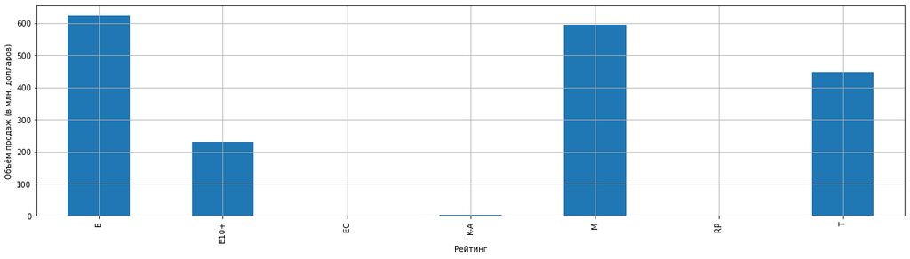

```python
df.pivot_table(index = 'Rating', values = 'NA_sales', aggfunc = 'sum').reset_index().plot(x = 'Rating', y = 'NA_sales',
kind = 'bar', grid = True, legend = False, figsize = (20, 5))
plt.xlabel('Рейтинг')
plt.ylabel('Объём продаж (в млн. долларов)')
plt.show()
```

Из данного графика видим, что игры с рейтингом EC, К-А и RP не пользуются большой популярностью, в то время как игры с рейтингом E и М бьют рекорды продаж и завоёвывают сердца игроков. Рейтинги E10+ и T заняли золотую серидину и чувствуют себя вполне хорошо - наелись и спят.

Таким образом, рейтинг всё же влияет на уровень продаж, однако зависимость не имеет линейный характер.

Посмотрим, справедлива ли данная зависимость для других регионов.

Европа.

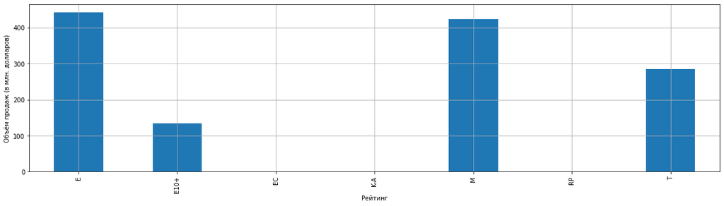

```python
df.pivot_table(index = 'Rating', values = 'EU_sales', aggfunc = 'sum').reset_index().plot(x = 'Rating', y = 'EU_sales',
kind = 'bar', grid = True, legend = False, figsize = (20, 5))
plt.xlabel('Рейтинг')
plt.ylabel('Объём продаж (в млн. долларов)')
plt.show()
```

Япония.

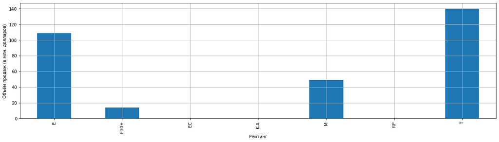

```python
df.pivot_table(index = 'Rating', values = 'JP_sales', aggfunc = 'sum').reset_index().plot(x = 'Rating', y = 'JP_sales',
kind = 'bar', grid = True, legend = False, figsize = (20, 5))
plt.xlabel('Рейтинг')
plt.ylabel('Объём продаж (в млн. долларов)')
plt.show()
```

Иные регионы.

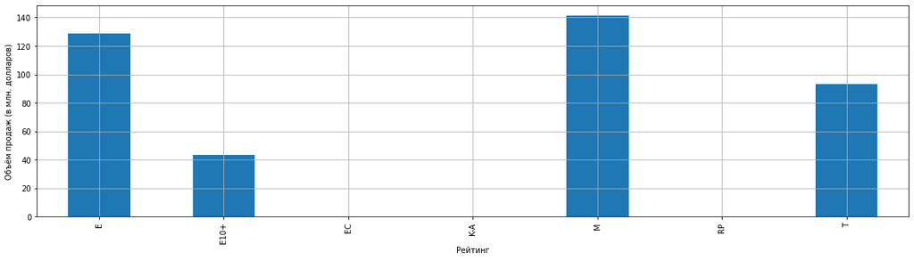

```python
df.pivot_table(index = 'Rating', values = 'Other_sales', aggfunc = 'sum').reset_index().plot(x = 'Rating', y = 'Other_sales',
kind = 'bar', grid = True, legend = False, figsize = (20, 5))
plt.xlabel('Рейтинг')
plt.ylabel('Объём продаж (в млн. долларов)')
plt.show()
```

А вот игры с рейтингами EC, К-А и RP не любят нигде, даже в Японии. Press f to pay respect!

# Вывод по этапу 4.

На данном этапе было осуществлено построение **портрета пользователя каждого региона.**

Напомню, что рамках данного этапа требовалось **определить:**

1. Самые популярные платформы (топ-5) (с описанием различий в долях продаж).
1. Самые популярные жанры (топ-5) (с пояснением разницы).
1. Влияние рейтинга ESRB на продажи в отдельном регионе.

# Этап 5. Построение гипотез и их проверка.

На данном этапе нужно проверить или опровергнуть следующие **гипотезы:**

1. Средние пользовательские рейтинги платформ Xbox One и PC одинаковые.
2. Средние пользовательские рейтинги жанров Action и Sports разные.

## Этап 5.1. Построение гипотезы "Средние пользовательские рейтинги платформ Xbox One и PC одинаковые" и её проверка.

Все необходимые данные содержатся в df.

Для проверки гипотезы нам нужны 2 среза: с оценками игроков для платформы XBox One и PC. Также для проверки гипотезы нам понадобится преобразование Series в массив данных Array. Используем метод values.

```python
users_score_xone = df[(df['Platform'] == "XOne") & (df['Year_of_Release'] >= 2008)]['User_Score'].values
users_score_pc = df[(df['Platform'] == "PC") & (df['Year_of_Release'] >= 2008)]['User_Score'].values
```

Формулируем нулевую гипотезу H0: средние пользовательские рейтинги платформ Xbox One и PC одинаковы.

Формулируем альтернативную гипотезу H1: средние пользовательские рейтинги платформ Xbox One и PC различаются.

Нулевая гипотеза формируется таким образом, чтобы результат проверки был для нас ожидаем и неизменен: если мы проверям отличие между двумя средними, нулевая гипотеза должна быть сформирована таким образом, что различий между средними не должно быть.

Условимся, что будем использовать уровень значимости 0.05 для проверки гипотез.

Теперь необходимо выбрать подходящий критерий проверки гипотезы. Для этого нужно понять, с каким распределением мы имеем дело - нормальным или отличным от нормального.

Чтобы это проверить, воспользуемся normaltest из библиотеки scipy.stats.

Гипотеза H0 - данные в выборке распределены нормально.

Гипотеза H1 - данные в выборке распределены как-то иначе.

Проверим, нормально ли распределены данные в users_score_xone.

```python
alpha = 0.05
results = st.normaltest(users_score_xone)
print('p-значение:', results.pvalue)
if results.pvalue < alpha:
    print('Нулевая гипотеза отклонена: распределение данных не является нормальным.')
else:
    print('Нулевая гипотеза подтверждена: данные распределены нормально.')
```

```
p-значение: 4.107412523722976e-14
Нулевая гипотеза отклонена: распределение данных не является нормальным.
```

То же проделаем и для users_score_pc.

```python
alpha = 0.05
results = st.normaltest(users_score_pc)
print('p-значение:', results.pvalue)
if results.pvalue < alpha:
    print('Нулевая гипотеза отклонена: распределение данных не является нормальным.')
else:
    print('Нулевая гипотеза подтверждена: данные распределены нормально.')
```

```
p-значение: 8.00063869390128e-31
Нулевая гипотеза отклонена: распределение данных не является нормальным.
```

Проверка гипотез показала, что при заданном уровне значимости распределение данных отличается от нормальных.

Таким образом, мы имеем 2 независимые друг от друга группы, данные в которых не подчиняются нормальному закону распределения. Следовательно, для проверки гипотезы о равенстве или различии средних пользовательских рейтингов платформ Xbox One и PC используем критерий Манна-Уитни.

```python
alpha = 0.05
results = st.mannwhitneyu(users_score_xone, users_score_pc)
print('Среднее значение пользовательской оценки для платформы XBox One:', round(np.mean(users_score_xone), 2))
print('Среднее значение пользовательской оценки для платформы PC:', round(np.mean(users_score_pc), 2))
print('p-значение:', results.pvalue)
if results.pvalue < alpha:
    print('Нулевая гипотеза отклонена: средние пользовательские рейтинги платформ Xbox One и PC различаются.')
else:
    print('Нулевая гипотеза подтверждена: Средние пользовательские рейтинги платформ Xbox One и PC одинаковые.')
```

```
Среднее значение пользовательской оценки для платформы XBox One: 6.76
Среднее значение пользовательской оценки для платформы PC: 6.9
p-значение: 0.0010750733760255973
Нулевая гипотеза отклонена: средние пользовательские рейтинги платформ Xbox One и PC различаются.
```

Нулевая гипотеза отклонена: оценки по платформам платформ Xbox One и PC различаются.

И ведь действительно различаются: учитывая, что верхняя граница оценки - 10, даже маленькая разбежка в оценках может по-разному описывать качество игры.

## Этап 5.2. Построение гипотезы "Средние пользовательские рейтинги жанров Action и Sports разные" и её проверка.

Порядок действий аналогичен этапу 5.1.

Сначала формируем 2 среза - пользовательские рейтинги с жанром Action и Sports - и делаем из них массивы данных.

```python
users_score_action = df[(df['Genre'] == "Action") & (df['Year_of_Release'] >= 2008)]['User_Score'].values
users_score_sports = df[(df['Genre'] == "Sports") & (df['Year_of_Release'] >= 2008)]['User_Score'].values
```

Формулируем нулевую гипотезу H0: средние пользовательские рейтинги жанров Action и Sports одинаковы.

Формулируем альтернативную гипотезу H1: средние пользовательские рейтинги жанров Action и Sports различаются.

Нулевая гипотеза формируется аналогичным этапу 5.1. образом.

Будем использовать тот же уровень значимости 0.05 для проверки гипотез.

Определим подходящий критерий проверки гипотезы. Постановка гипотез та же:

Гипотеза H0 - данные в выборке распределены нормально.

Гипотеза H1 - данные в выборке распределены как-то иначе.

Проверим, нормально ли распределены данные в users_score_action.

```python
alpha = 0.05
results = st.normaltest(users_score_action)
print('p-значение:', results.pvalue)
if results.pvalue < alpha:
    print('Нулевая гипотеза отклонена: распределение данных не является нормальным.')
else:
    print('Нулевая гипотеза подтверждена: данные распределены нормально.')
```

```
p-значение: 8.943111885159352e-116
Нулевая гипотеза отклонена: распределение данных не является нормальным.
```

Проделаем то же для users_score_sports.

```python
alpha = 0.05
results = st.normaltest(users_score_sports)
print('p-значение:', results.pvalue)
if results.pvalue < alpha:
    print('Нулевая гипотеза отклонена: распределение данных не является нормальным.')
else:
    print('Нулевая гипотеза подтверждена: данные распределены нормально.')
```

```
p-значение: 1.1844548087163702e-46
Нулевая гипотеза отклонена: распределение данных не является нормальным.
```

Как и на этапе 5.1., проверка гипотез показала, что при заданном уровне значимости распределение данных отличается от нормальных.

Таким образом, мы имеем 2 независимые друг от друга группы, данные в которых не подчиняются нормальному закону распределения. Следовательно, для проверки гипотезы о равенстве или различии средних пользовательских рейтингов жанров Action и Sports снова используем критерий Манна-Уитни.

```python
alpha = 0.05
results = st.mannwhitneyu(users_score_action, users_score_sports)
print('Среднее значение пользовательской оценки для жанра Action:', round(np.mean(users_score_action), 2))
print('Среднее значение пользовательской оценки для жанра Sports:', round(np.mean(users_score_sports), 2))
print('p-значение:', results.pvalue)
if results.pvalue < alpha:
    print('Нулевая гипотеза отклонена: средние пользовательские рейтинги жанров Action и Sports различаются.')
else:
    print('Нулевая гипотеза подтверждена: Средние пользовательские рейтинги жанров Action и Sports одинаковые.')
```

```
Среднее значение пользовательской оценки для жанра Action: 7.06
Среднее значение пользовательской оценки для жанра Sports: 6.63
p-значение: 1.5485516266310997e-10
Нулевая гипотеза отклонена: средние пользовательские рейтинги жанров Action и Sports различаются.
```

Нулевая гипотеза отклонена: оценки по жанрам Action и Sports различаются.

И, опять же, в силу небольшой верхней границы оценки, даже столь небольше различие в оценках может быть существенным.

# Вывод по этапу 5.

На данном этапе требовалось проверить или опровергнуть следующие **гипотезы:**

1. Средние пользовательские рейтинги платформ XBox One и PC одинаковые.
2. Средние пользовательские рейтинги жанров Action и Sports разные.

# Общий вывод по проекту.

В рамках проекта мы работали с **информацией** о деловой активности интернет-магазина компьютерных игр «Стримчик» с 1985 года по 2016 год.

В рамках проекта мы располагали **данными** о продажах игр, оценках пользователей и экспертов, жанрах и платформах, а также о рейтинге игр.

**Целью** проекта являлось определение факторов, оказывающих наибольшее влияние на успешность игры.

**Решение**, выработанное в рамках проекта, позволит компании спланировать рекламные кампании, фокусируясь на наиболее востребованных продуктах, в целях **увеличения объёмов продаж и максимизации прибыли**.

В рамках проекта было **необходимо:**

1. Рассчитать **дополнительные параметры:**

1.1. Суммарные продажи во всех регионах.

1. Ответить на ряд **вопросов:**

2.1. Сколько игр выпускалось в разные годы. Важны ли данные за все периоды?

2.2. Как менялись продажи по платформам? За какой характерный срок появляются новые и исчезают старые платформы?

2.3. Как определить актуальный период, пригодный для построения прогноза на 2017 год.

2.4. Какие платформы лидируют по продажам, растут или падают? Можно ли выбрать несколько потенциально прибыльных платформ?

2.5. Как влияют на продажи внутри одной популярной платформы отзывы пользователей и критиков? Как можно соотнести полученные выводы с продажами игр на других платформах?

2.6. Что можно сказать об общем распределении игр по жанрам? Что можно сказать о самых прибыльных жанрах? Выделяются ли жанры с высокими и низкими продажами?

1. **Определить** для пользователя каждого региона (NA, EU, JP):

3.1. Самые популярные платформы (топ-5) (с описанием различий в долях продаж).

3.2. Самые популярные жанры (топ-5) (с пояснением разницы).

3.3. Влияние рейтинга ESRB на продажи в отдельном регионе.

1. Подтвердить или опровергнуть следующие **гипотезы:**

4.1. Средние пользовательские рейтинги платформ Xbox One и PC одинаковые.

4.2. Средние пользовательские рейтинги жанров Action и Sports разные.

Работа над проектом велась в следующем **порядке:**

1. Чтение данных, их изучение, поиск аномальных и пропущенных значений в данных.
1. Предварительная обработка данных, расчёт дополнительных парамтеров.
1. Анализ данных.
1. Построение портрета пользователя каждого региона.
1. Построение гипотез и их проверка.

## **Этап 1.**

На данном этапе были **импортированы необходимые для работы библиотеки**, а также был **прочитан и проанализирован предложенный набор данных.**

Для получения информации о df была написана соответствующая функция.

DF состоит из **16 715 строк и 11 полей**, из которых:

- 5 полей - категориальные (тип - object);
- 6 полей - дробные числовые значения (тип - float).

В DF **отсутствуют дубликаты**, однако наблюдаются **пропущенные значения:**

- поле Name - 2 пропущенных значения;
- поле Year_of_Release - 269 пропущенных значений;
- поле Genrе - 2 пропущенных значения;
- поле Critic_Score - 8 578 пропущенных значений;
- поле User_Score - 6 701 пропущенное значение;
- Rating - 6 766 пропущенных значений.

Отметим особенности набора данных, на которые нужно будет обратить внимание в ходе работы с ним:

1. В поле **Name** есть записи, которые встречаются больше 1 раза. Так как речь идёт о рейтинге игры, изначально упоминание одного наименования более одного раза вызывает вопросы. Стоит проверить, есть ли какие-то различия между записями, где одно название упоминается более 1 раза.
1. В поле **Year_of_Release** даты релиза игр приведены в дробном значении (тип float), их будет корректнее привести к типу int.
1. В поле **User_Score**, описывающий оценку игры со стороны игроков, данные записаны в типе object, их нужно свести к типу float.
1. В полях **NA_sales, JP_sales, EU_sales и Other_sales**, которые описывают продажи в Серевной Америке, Европе, Японии и других странах соответственно (в миллионах долларов), содержится большое количество записей с объёмом продаж, равным нулю. С учётом того, что данные приведены в типе float с округлением до двух знаков до запятой, мы увидим объём продаж, если он равен или превышает 10 000 долларов. Теоретически, объём продаж может быть ниже 10 000 долларов, и в таком случае он будет записан как 0.00, хотя это не будет означать, что продаж по этой игре не было. С другой стороны, теоретически игра действительно могла просто не продаваться, так как ещё до релиза её могли разгромить критики. В любом случае, независимо от гипотезы, стоит посмотреть на рейтинг игр с объёмом продаж 0.00 миллионов долларов: если рейтинг низкий - мы, скорее всего, имеем дело с играми никзкого качества, если рейтинг высокий - данные о продажах данных игр отсутствуют.
1. В поле **User_Score** присутствует значение tbd (2 424 записи). Нужно их проанализировать и выяснить их природу.

## **Этап 2.**

На данном этапе происходила предварительная обработка данных.

Напомним, что она происходила по следующим направлениям:

1. Преобразование типов данных.
1. Обработка аномальных значений.
1. Обработка пропущенных значений.
1. Расчёт дополнительных параметров.

При **преобразовании типов данных** исследовались поля Year_of_Release и User_Score.

В поле Year_of_Release описана дата релиза игры, однако данные были приведены в типе float. Эти данные мы привели к типу int.

В поле User_Score данные были приведены в типе object, а также в этом поле были аномальные значения tbd. С этим полем мы работали на этапе обработки аномальных значений.

При **обработке аномальных значений** мы исследовали следующие поля:

1. Name (аномалия - записи, которые встречаются больше 1 раза).
2. NA_sales, JP_sales, EU_sales и Other_sales (аномалия - продажи со значением 0.00 млн. долларов).
3. User_Score (аномалия - значение tbd).

При исследовании поля **Name** мы выяснили, что упоминание наименования игры более 1 раза связано с тем, что игра могла быть выпущена для разных платформ и в разное время (например, сначала была выпущена оригинальная игра, в последующем - ремастер/ремейк/перезапуск).

При исследовании полей **NA_sales, JP_sales, EU_sales и Other_sales** мы выяснили, что только для двух записей характерно отсутствие продаж во всех регионах, для них также отсутствуют оценки критиков и игроков, а также рейтинг. Так как записи всего две, было принято решение их проигнорировать. В остальном же мы пришли к выводу, что наличие нулевых продаж в одном регионе при наличии продаж в другом регионе - нормальная практика, так как речь идёт о продажах только одной компании, которая может слабо присутствовать в том или ином регионе.

При исследовании поля **User_Score** мы не установили зависимостей между этим полем и, очевидно, наиболее важными полями, которые, в теории, могли бы объяснить природу аномальных значений tbd: Platform, Year_of_Release и Genre. Учитывая смысл аббревиатуры tbd (To Be Determined), что означает, что какой-то параметр, которому присвоена данная аббревиатура, будет определён позже (обычно это характерно для дат релиза игр или дат получения оценок критиков или игроков), мы пришли к выводу, что данные об оценке этой игры игроками должны были быть получены позже, но так и не были получены. Поэтому они были обработаны с помощью метода to_numeric, который переводит строковые данные в данные типа float, при этом в качестве аргумента параметру errors мы передали значение coerce, что означает, что все исключения (которыми являются значения tbd, так как их нельзя перевести в float) были заменены на NaN.

При **обработке пропущенных значений** мы исследовали следующие поля:

1. Поле Name - 2 пропущенных значения.
1. Поле Year_of_Release - 269 пропущенных значений.
1. Поле Genrе - 2 пропущенных значения.
1. Поле Critic_Score - 8 578 пропущенных значений.
1. Поле User_Score - 6 701 пропущенное значение.
1. Поле Rating - 6 766 пропущенных значений.

Пропущенные значения в полях **Name, Year_of_Release и Genrе** были обработаны путём удаления из df строк с пропущенными значениями в этих полях. Отмечу, что мы также обнаружили, что строки, где в полях Name и Genre значения пропущены - это одни и те же строки.

Пропущенные значения в полях **Critic_Score, User_Score и Rating** были заменены на соответствующие медианные значения, рассчитанные для каждого жанра игры.

В ходе **расчёта дополнительных параметров** были рассчитаны суммарные продажи игр по всем регионам.

## **Этап 3.**

На данном этапе был проведён **анализ данных.**

Напомню, что в рамках этого этапа требовалось ответить на следующие **вопросы:**

1. Сколько игр выпускалось в разные годы. Важны ли данные за все периоды?
1. Как менялись продажи по платформам? За какой характерный срок появляются новые и исчезают старые платформы?
1. Как определить актуальный период, пригодный для построения прогноза на 2017 год.
1. Какие платформы лидируют по продажам, растут или падают? Можно ли выбрать несколько потенциально прибыльных платформ?
1. Как влияют на продажи внутри одной популярной платформы отзывы пользователей и критиков? Как можно соотнести полученные выводы с продажами игр на других платформах?
1. Что можно сказать об общем распределении игр по жанрам? Что можно сказать о самых прибыльных жанрах? Выделяются ли жанры с высокими и низкими продажами?

Отметим следующие **выводы:**

1. Подъём в выпуске игр приходится на 1994 год. До этого года игры выпускались досаточно вяло в силу, возможно, неразвитости технологий. Очевидный пик в развитии игровой индустрии пришёлся на 2000-2011 годы, а с 2012 года наблюдается некоторое снижение количества реализованных игр, вероятно, из-за кризиса. Количество реализованных игр в 2016 году - последнем в нашей выборке - находится на уровне 2001 года, однако мы знаем, что за 2016 год данные могут быть неполными.
1. Жизненный цикл платформы, в среднем, составляет 8 лет, из которых примерно 5 лет - это стадия роста, 3 года - стадия спада. Учитывая цикличный характер развития отрасли, доказанный с помощью графиков, можно предположить, что 2016 год, учитывая падение продаж на протяжении 3 лет до него, станет годом, на который придётся оживление отрасли, а последующие 4 года - в том числе и интересующий нас 2017 год - станут годами роста продаж.
1. Актуальный период для построения прогноза был определён из средней длительности жизненного цикла платформы - 8 лет. С помощью этой информации был спрогнозирован рост продаж в 2017 году, так как в отрасли ожидается подъём после трёхлетнего спада. При этом актуальным периодом для анализа данных можно считать период с 2008 года по 2016 год опять-таки из средней длительности жизненного цикла платформы.
1. Все платформы так или иначе на последнюю доступную дату показывали снижение продаж, что было объяснено их нахождением на стадии спада. Был выявлен список актуальных платформ, которые лучше всего подходят для прогноза: Wii, X360, PS3, PS4, 3DS, PC, XOne, WiiU и PSV. При этом платформа считается актуальной, если для неё есть продажи с 2008 года и если для неё выпускаются игры в 2016 году. Также для суммарного объёма продаж были построены ящики с усами в зависимости от платформы. На всех ящиках с усами мы видели одинаковую картину: медиана внутри ящика скошена в левую сторону (или к нижней части оси y), что также вписывается в картину определённого жизненного цикла платформы: так как в течение 3 лет продажи падают, а затем в течение 5 лет растут, прибыль, полученная на этапе роста, может быть расценена как выброс относительно всего цикла продаж, в котром есть также низкие продажи из этапа падения. Очевидно также, что пик продаж (4-5 год на стадии роста) на данных графиков всегда оценивается как выбросы, что мы также видели на графиках.
1. Для оценки зависимости объёма продаж от оценки критиков/пользователей была построена диаграмма рассеяния, которая позволила сформировать гипотезу о незначительном влиянии оценок критиков/пользователей на продажи. Гипотеза была проверена с помощью коэффициента корреляции, значения которого показали наличие средней прямой линейной зависимости между суммарным объёмом продаж и оценкой критиков и слабой прямой линейной зависимости между суммарным объёмом продаж и оценкой игроков. Изначальное исследование проводилось для платформы PS3, впоследствии эти выводы мы подтвердили для всех платформ.
1. Как с точки зрения суммарных объёмов продаж, так и с точки зерния количества выпущенных в жанре игр, наиболее популярным жанромоказался жанр Action, наименее популярным - Puzzle.

## **Этап 4**

На данном этапе было осуществлено построение **портрета пользователя каждого региона.**

Напомню, что рамках данного этапа требовалось **определить:**

1. Самые популярные платформы (топ-5) (с описанием различий в долях продаж).
1. Самые популярные жанры (топ-5) (с пояснением разницы).
1. Влияние рейтинга ESRB на продажи в отдельном регионе.

## **Этап 5.**

На данном этапе требовалось проверить или опровергнуть следующие **гипотезы:**

1. Средние пользовательские рейтинги платформ XBox One и PC одинаковые.
1. Средние пользовательские рейтинги жанров Action и Sports разные.